# PKPD Analysis

Sara Angelucci and John Shorter

2025-10-28

# Load libraries.

```r
library(tidyverse)
```

```r
library(ggplot2)
library(readxl)
library(table1)
library(lme4)
library(dplyr)
library(Hmisc)
library(table1)
library(d3Network)
library(igraph)
library(networkD3) #New one to help with Sankey diagram.
library(corrplot)
library(ggcorrplot)
library(likert)
library(ggpubr)
library(ggsankey)
library(tidyr)
library(knitr)
library(kableExtra)
library(scales)
library(emmeans)
library(stats)
```

# Let`s read in the data, one that is all data points, another that is only first visit. Load and remove the 2 patients from the data file.

```r
setwd("C:/Users/saraa/Downloads/PKPD")
#setwd("~/PKPD_PER")
#"C:/Users/johnsh/OneDrive - Roskilde Universitet/Documents/PKPD_PER"

PKPD_JRS_transposed_all <- read_excel("PKPD_JRS_transposed_JRS_SA_7new.xlsx")
PKPD_JRS_transposed_all <- PKPD_JRS_transposed_all[!(PKPD_JRS_transposed_all$Name %in% c('Patient  16', 'Patient  65')), ]

PKPD_JRS_transposed_all <- PKPD_JRS_transposed_all %>%
    dplyr::filter(!is.na(`Perampanel blood test value`))

PKPD_JRS_transposed_all <- PKPD_JRS_transposed_all %>%
    dplyr::filter(!is.na(`Beneficial effect on seizures 3 months AFTER perampanel start (0=no, 1=yes) FIXED`))

PKPD_JRS_transposed_all <- PKPD_JRS_transposed_all %>%
    dplyr::filter(`Dose of PER from list of medications column` != 0)

# subset data set
PKPD_JRS_transposed <- read_excel("PKPD_JRS_transposed-Sara_JRS_1VisitxPatient.xlsx")

PKPD_JRS_transposed <- PKPD_JRS_transposed[!(PKPD_JRS_transposed$Name %in% c('Patient  16', 'Patient  65')), ]

PKPD_JRS_transposed <- PKPD_JRS_transposed %>%
    dplyr::filter(!is.na(`Perampanel blood test value`))

PKPD_JRS_transposed <- PKPD_JRS_transposed %>%
    dplyr::filter(!is.na(`Beneficial effect on seizures 3 months AFTER perampanel start (0=no, 1=yes) FIXED`))

PKPD_JRS_transposed <- PKPD_JRS_transposed %>%
    dplyr::filter(`Dose of PER from list of medications column` != 0)
```

## Looks like there is a now a duplicated column with the same title. R has changed this for us.

# Make a few plots, first number of visits.

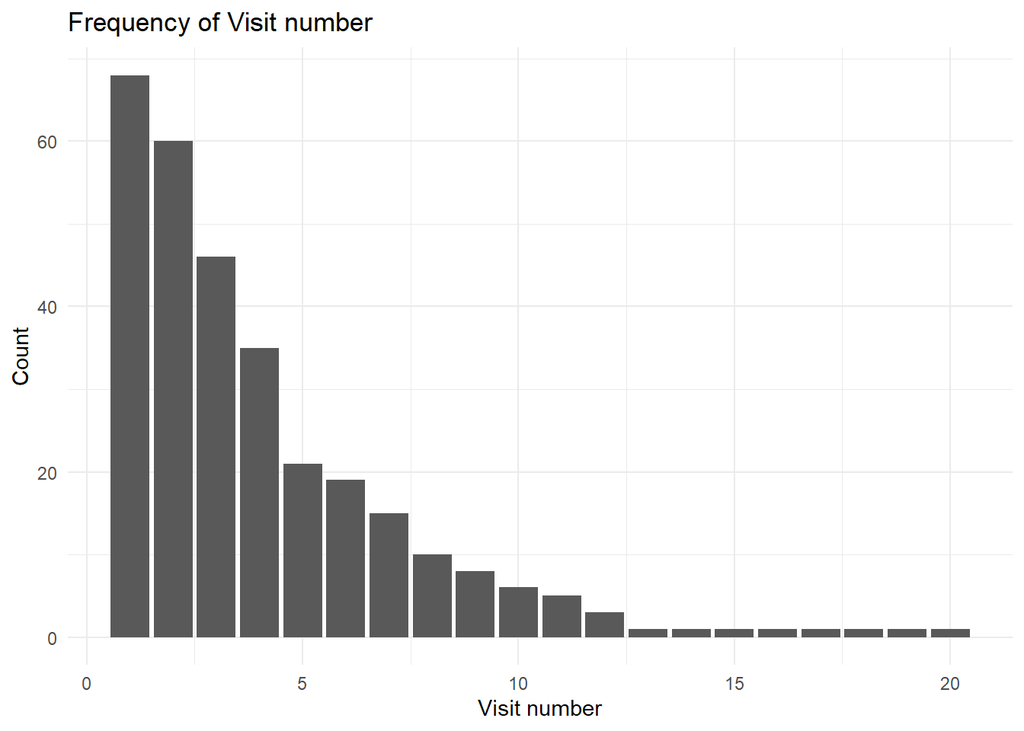

```r
ggplot(data = PKPD_JRS_transposed_all, aes(x = Visit_number)) +
  geom_bar() +
  labs(title = "Frequency of Visit number",
       x = "Visit number",
       y = "Count") +
  theme_minimal()
```

## Next plot, gender.

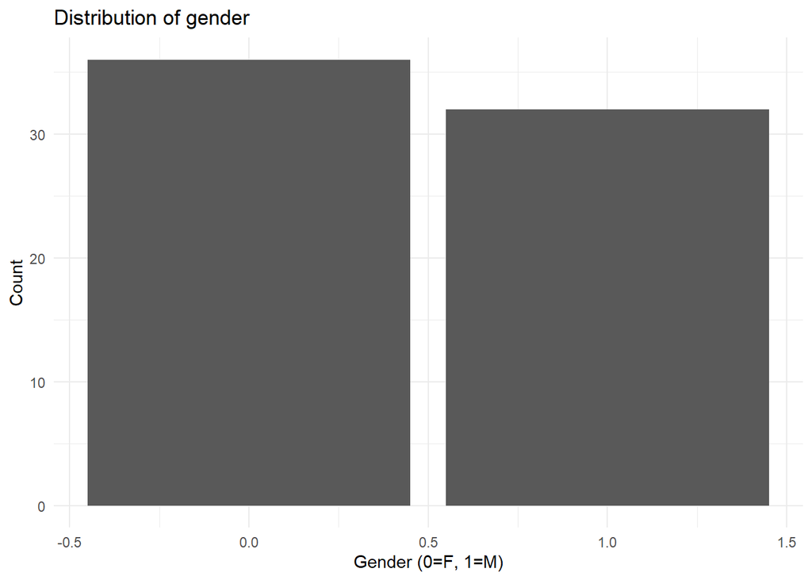

```r
ggplot(data = PKPD_JRS_transposed, aes(x = `Gender (0=F, 1=M)`)) +
  geom_bar() +
  labs(title = "Distribution of gender",
       x = "Gender (0=F, 1=M)",
       y = "Count") +
  theme_minimal()
```

## Next plot, current age, full years.

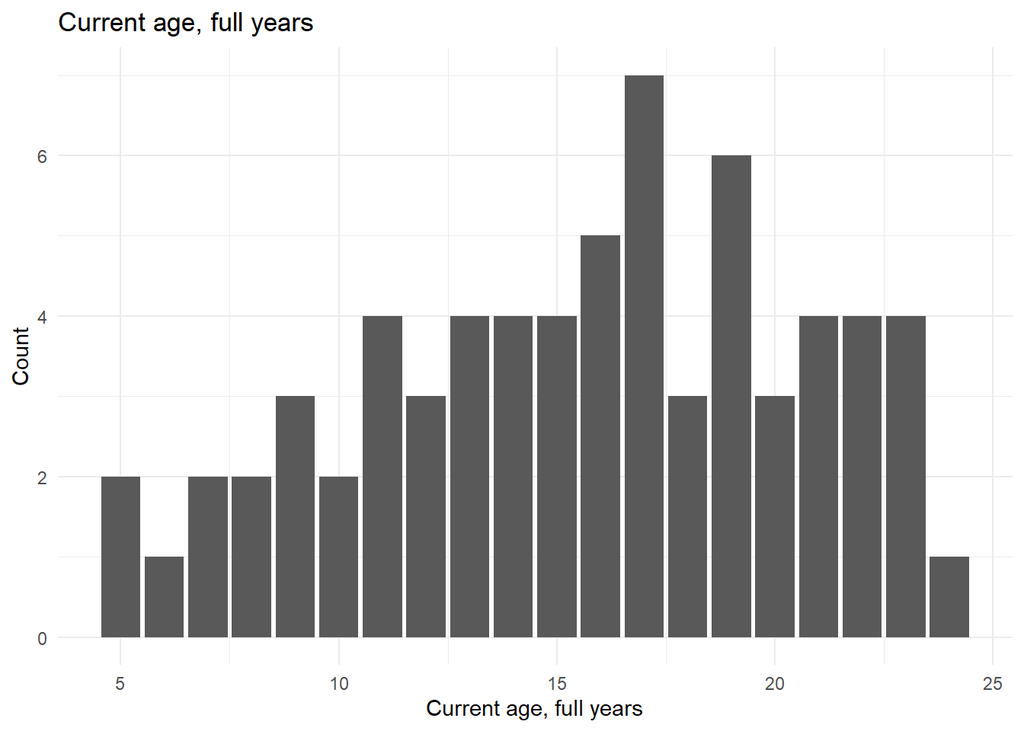

```r
ggplot(data = PKPD_JRS_transposed, aes(x = `Current age, full years`)) +
  geom_bar() +
  labs(title = "Current age, full years",
       x = "Current age, full years",
       y = "Count") +
  theme_minimal()
```

## BMI histogram.

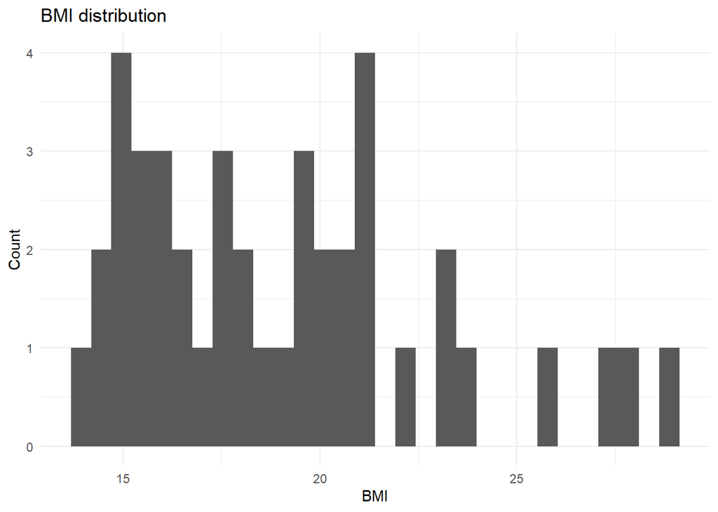

```r
ggplot(data = PKPD_JRS_transposed, aes(x = `BMI (kg/m^2)`)) +
  geom_histogram() +
  labs(title = "BMI distribution",
       x = "BMI",
       y = "Count") +
  theme_minimal()
```

## Beneficial effect on seizures 3 months AFTER perampanel start against weight.

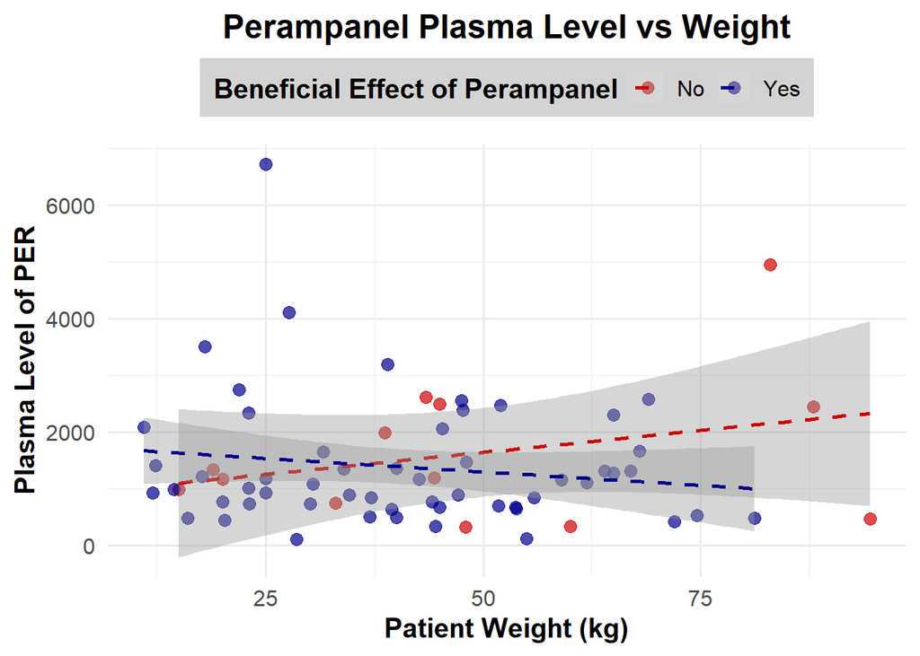

```r
PKPD_JRS_transposed$`Weight at plasma measure` <- as.numeric(PKPD_JRS_transposed$`Weight at plasma measure`)

PKPD_JRS_transposed$`Beneficial effect (0=no, 1=yes) FIXED` <- as.factor(PKPD_JRS_transposed$`Beneficial effect on seizures 3 months AFTER perampanel start (0=no, 1=yes) FIXED`)

ggplot(data = PKPD_JRS_transposed, aes(x = `Weight at plasma measure`,
                                       y = `Perampanel blood test value`,
                                       color = `Beneficial effect (0=no, 1=yes) FIXED`)) +
  geom_point(size = 3, alpha = 0.7) +  # Adjust point size and transparency
  geom_smooth(method = "lm", se = TRUE, linetype = "dashed", size = 1) +  # Add dashed regression lines
  labs(title = "Perampanel Plasma Level vs Weight",
       x = "Patient Weight (kg)",
       y = "Plasma Level of PER",
       color = "Beneficial Effect of Perampanel") +
  theme_minimal(base_size = 15) +  # Use a larger base size for better readability
  scale_color_manual(values = c("0" = "red3", "1" = "blue4"),  # Custom color scheme
                     labels = c("No", "Yes")) +  # Custom labels for the legend
  theme(
    plot.title = element_text(hjust = 0.5, face = "bold"),  # Center and bold the title
    axis.title = element_text(face = "bold"),  # Bold the axis titles
    legend.position = "top",  # Position the legend at the top
    legend.title = element_text(face = "bold"),  # Bold the legend title
    legend.background = element_rect(fill = "lightgray", color = NA),  # Light gray background for legend
    legend.key = element_rect(fill = "white", color = NA)  # White background for legend keys
  )
```

## Beneficial effect on seizures 3 months AFTER perampanel start against mg/kg.

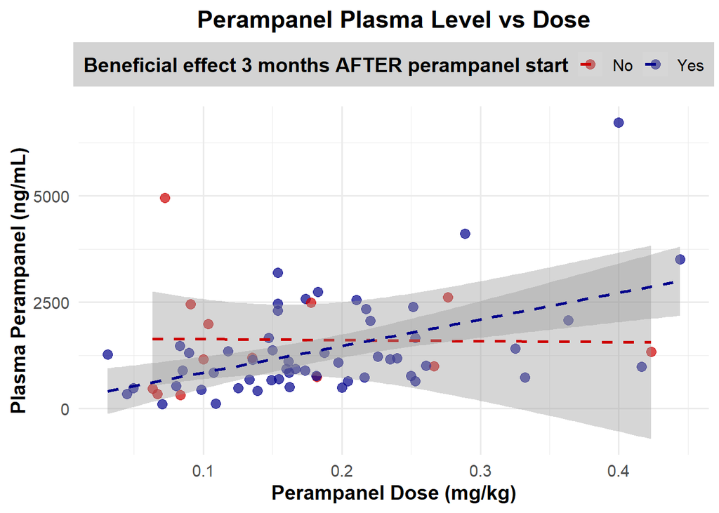

```r
PKPD_JRS_transposed$`PER dose` <- as.numeric(PKPD_JRS_transposed$`Dose of PER from list of medications column`)

PKPD_JRS_transposed$mgkg =  PKPD_JRS_transposed$`PER dose`/PKPD_JRS_transposed$`Weight at plasma measure`

ggplot(data = PKPD_JRS_transposed, aes(x = `mgkg`,
                                       y = `Perampanel blood test value`,
                                       color = `Beneficial effect (0=no, 1=yes) FIXED`)) +
geom_point(size = 3, alpha = 0.7) +  # Adjust point size and transparency
#geom_jitter(size = 3, alpha = 0.7, width = 0.3, height = 0, seed = 666) +  # Add jitter to points
geom_smooth(method = "lm", se = TRUE, linetype = "dashed", size = 1) +  # Add dashed regression lines
  labs(title = "Perampanel Plasma Level vs Dose",
       x = "Perampanel Dose (mg/kg)",
       y = "Plasma Perampanel (ng/mL)",
       color = "Beneficial effect 3 months AFTER perampanel start") +
  theme_minimal(base_size = 14) +  # Use a larger base size for better readability
  scale_color_manual(values = c("0" = "red3", "1" = "blue4"),  # Custom color scheme
                     labels = c("No", "Yes")) +  # Custom labels for the legend
  theme(
    plot.title = element_text(hjust = 0.5, face = "bold"),  # Center and bold the title
    axis.title = element_text(face = "bold"),  # Bold the axis titles
    legend.position = "top",  # Position the legend at the top
    legend.title = element_text(face = "bold"),  # Bold the legend title
    legend.background = element_rect(fill = "lightgray", color = NA),  # Light gray background for legend
    legend.key = element_rect(fill = "white", color = NA)  # White background for legend keys
  )
```

## Did the Patient become seizure free on perampanel against mg/kg.

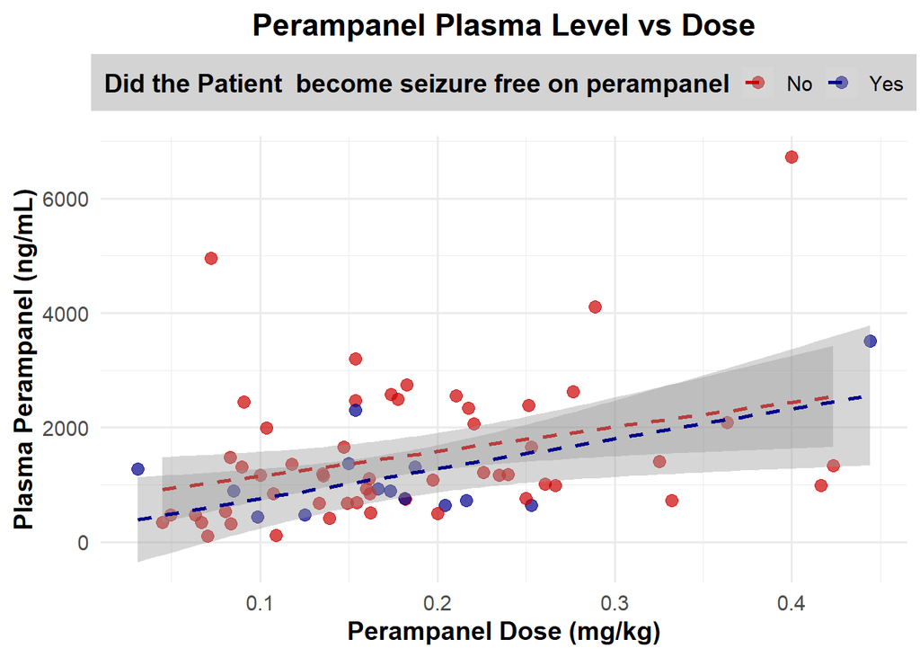

```r
PKPD_JRS_transposed$`PER dose` <- as.numeric(PKPD_JRS_transposed$`Dose of PER from list of medications column`)
PKPD_JRS_transposed$`Did the Patient become seizure free on perampanel? (0=no, 1=yes)` <- as.factor(PKPD_JRS_transposed$`Did the Patient  become seizure free on perampanel? (0=no, 1=yes)`)

PKPD_JRS_transposed$mgkg =  PKPD_JRS_transposed$`PER dose`/PKPD_JRS_transposed$`Weight at plasma measure`

ggplot(data = PKPD_JRS_transposed, aes(x = `mgkg`,
                                       y = `Perampanel blood test value`,
                                       color = `Did the Patient become seizure free on perampanel? (0=no, 1=yes)`)) +
geom_point(size = 3, alpha = 0.7) +  # Adjust point size and transparency
#geom_jitter(size = 3, alpha = 0.7, width = 0.3, height = 0, seed = 666) +  # Add jitter to points
geom_smooth(method = "lm", se = TRUE, linetype = "dashed", size = 1) +  # Add dashed regression lines
  labs(title = "Perampanel Plasma Level vs Dose",
       x = "Perampanel Dose (mg/kg)",
       y = "Plasma Perampanel (ng/mL)",
       color = "Did the Patient  become seizure free on perampanel") +
  theme_minimal(base_size = 14) +  # Use a larger base size for better readability
  scale_color_manual(values = c("0" = "red3", "1" = "blue4"),  # Custom color scheme
                     labels = c("No", "Yes")) +  # Custom labels for the legend
  theme(
    plot.title = element_text(hjust = 0.5, face = "bold"),  # Center and bold the title
    axis.title = element_text(face = "bold"),  # Bold the axis titles
    legend.position = "top",  # Position the legend at the top
    legend.title = element_text(face = "bold"),  # Bold the legend title
    legend.background = element_rect(fill = "lightgray", color = NA),  # Light gray background for legend
    legend.key = element_rect(fill = "white", color = NA)  # White background for legend keys
  )
```

## Plotting side effects of PER against mg/kg.

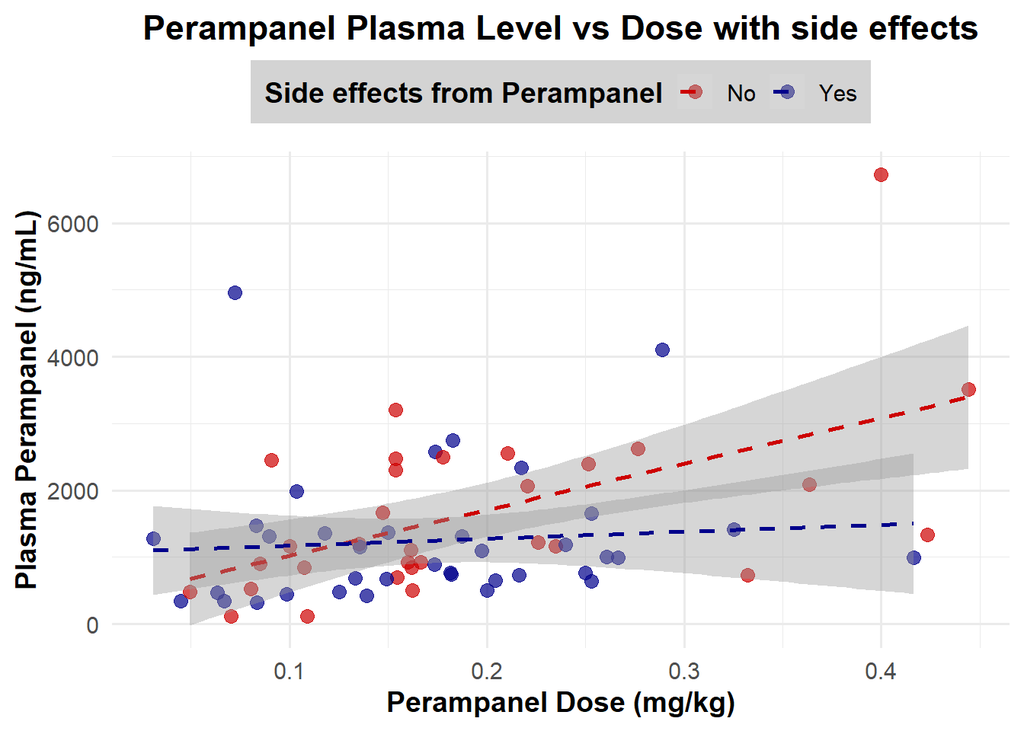

```r
PKPD_JRS_transposed$`side effects FIXED` <- as.factor(PKPD_JRS_transposed$`side effects (0 = none, 1=something)`)

ggplot(data = PKPD_JRS_transposed, aes(x = `mgkg`,
                                       y = `Perampanel blood test value`,
                                       color = `side effects FIXED`)) +
  geom_point(size = 3, alpha = 0.7) +  # Adjust point size and transparency
  #geom_jitter(size = 3, alpha = 0.7, width = 0.3, height = 0, seed = 666) +  # Add jitter to points
  geom_smooth(method = "lm", se = TRUE, linetype = "dashed", size = 1) +  # Add dashed regression lines
  labs(title = "Perampanel Plasma Level vs Dose with side effects",
       x = "Perampanel Dose (mg/kg)",
       y = "Plasma Perampanel (ng/mL)",
       color = "Side effects from Perampanel") +
  theme_minimal(base_size = 14) +  # Use a larger base size for better readability
  scale_color_manual(values = c("0" = "red3", "1" = "blue4"),  # Custom color scheme
                     labels = c("No", "Yes")) +  # Custom labels for the legend
  theme(
    plot.title = element_text(hjust = 0.5, face = "bold"),  # Center and bold the title
    axis.title = element_text(face = "bold"),  # Bold the axis titles
    legend.position = "top",  # Position the legend at the top
    legend.title = element_text(face = "bold"),  # Bold the legend title
    legend.background = element_rect(fill = "lightgray", color = NA),  # Light gray background for legend
    legend.key = element_rect(fill = "white", color = NA)  # White background for legend keys
  )
```

## Beneficial effect on seizures 3 months AFTER perampanel start against mg/kg with all data points.

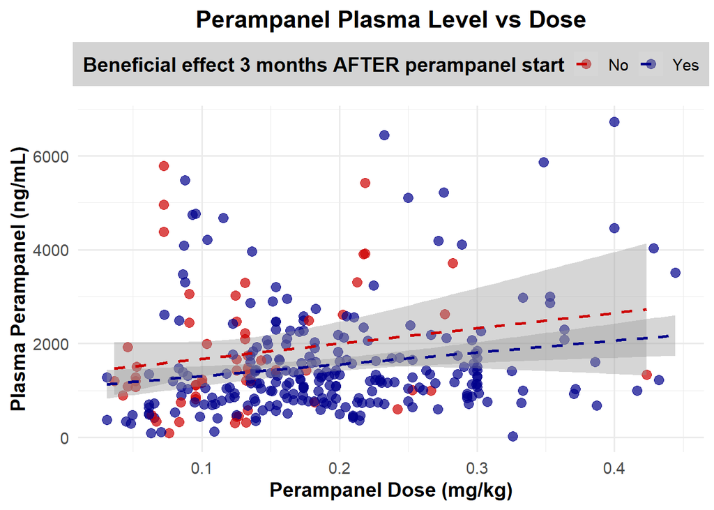

```r
PKPD_JRS_transposed_all$`Weight at plasma measure` <- as.numeric(PKPD_JRS_transposed_all$`Weight at plasma measure`)

PKPD_JRS_transposed_all$`Beneficial effect (0=no, 1=yes) FIXED` <- as.factor(PKPD_JRS_transposed_all$`Beneficial effect on seizures 3 months AFTER perampanel start (0=no, 1=yes) FIXED`)

PKPD_JRS_transposed_all$`PER dose` <- as.numeric(PKPD_JRS_transposed_all$`Dose of PER from list of medications column`)

PKPD_JRS_transposed_all$mgkg =  PKPD_JRS_transposed_all$`PER dose`/PKPD_JRS_transposed_all$`Weight at plasma measure`

ggplot(data = PKPD_JRS_transposed_all, aes(x = `mgkg`,
                                       y = `Perampanel blood test value`,
                                       color = `Beneficial effect (0=no, 1=yes) FIXED`)) +
geom_point(size = 3, alpha = 0.7) +  # Adjust point size and transparency
#geom_jitter(size = 3, alpha = 0.7, width = 0.3, height = 0, seed = 666) +  # Add jitter to points
geom_smooth(method = "lm", se = TRUE, linetype = "dashed", size = 1) +  # Add dashed regression lines
  labs(title = "Perampanel Plasma Level vs Dose",
       x = "Perampanel Dose (mg/kg)",
       y = "Plasma Perampanel (ng/mL)",
       color = "Beneficial effect 3 months AFTER perampanel start") +
  theme_minimal(base_size = 14) +  # Use a larger base size for better readability
  scale_color_manual(values = c("0" = "red3", "1" = "blue4"),  # Custom color scheme
                     labels = c("No", "Yes")) +  # Custom labels for the legend
  theme(
    plot.title = element_text(hjust = 0.5, face = "bold"),  # Center and bold the title
    axis.title = element_text(face = "bold"),  # Bold the axis titles
    legend.position = "top",  # Position the legend at the top
    legend.title = element_text(face = "bold"),  # Bold the legend title
    legend.background = element_rect(fill = "lightgray", color = NA),  # Light gray background for legend
    legend.key = element_rect(fill = "white", color = NA)  # White background for legend keys
  )
```

## Did the Patient become seizure free on perampanel against mg/kg with all data points.

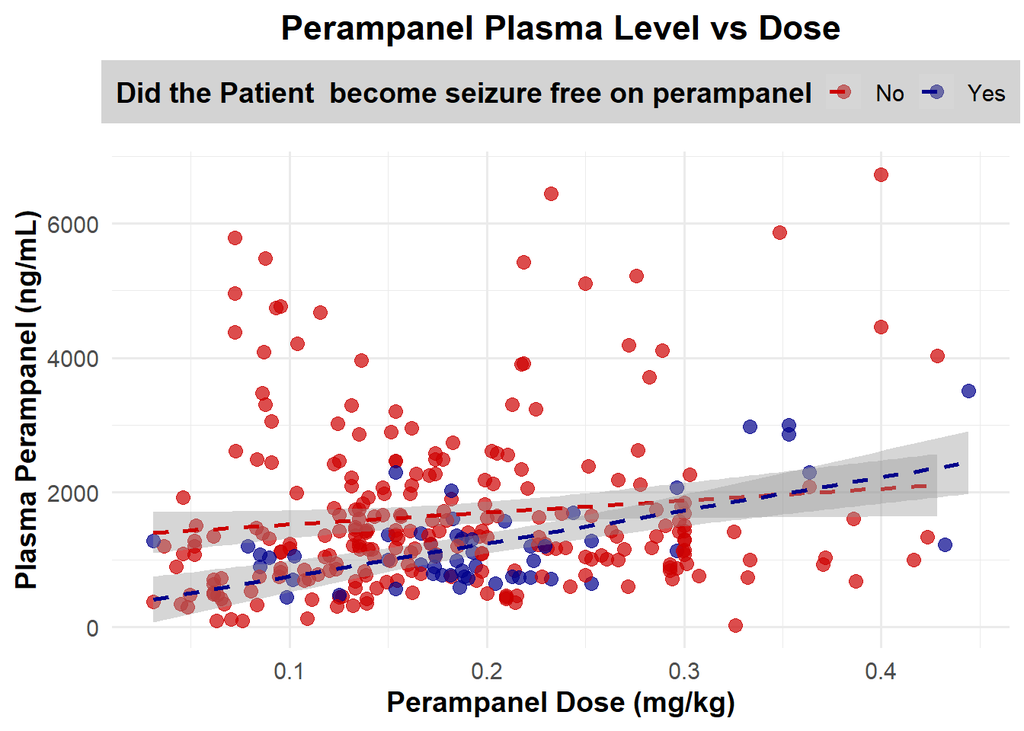

```r
PKPD_JRS_transposed_all$`PER dose` <- as.numeric(PKPD_JRS_transposed_all$`Dose of PER from list of medications column`)

PKPD_JRS_transposed_all$`Did the Patient become seizure free on perampanel? (0=no, 1=yes)` <- as.factor(PKPD_JRS_transposed_all$`Did the Patient  become seizure free on perampanel? (0=no, 1=yes)`)

PKPD_JRS_transposed_all$mgkg =  PKPD_JRS_transposed_all$`PER dose`/PKPD_JRS_transposed_all$`Weight at plasma measure`

ggplot(data = PKPD_JRS_transposed_all, aes(x = `mgkg`,
                                       y = `Perampanel blood test value`,
                                       color = `Did the Patient become seizure free on perampanel? (0=no, 1=yes)`)) +
geom_point(size = 3, alpha = 0.7) +  # Adjust point size and transparency
#geom_jitter(size = 3, alpha = 0.7, width = 0.3, height = 0, seed = 666) +  # Add jitter to points
geom_smooth(method = "lm", se = TRUE, linetype = "dashed", size = 1) +  # Add dashed regression lines
  labs(title = "Perampanel Plasma Level vs Dose",
       x = "Perampanel Dose (mg/kg)",
       y = "Plasma Perampanel (ng/mL)",
       color = "Did the Patient  become seizure free on perampanel") +
  theme_minimal(base_size = 14) +  # Use a larger base size for better readability
  scale_color_manual(values = c("0" = "red3", "1" = "blue4"),  # Custom color scheme
                     labels = c("No", "Yes")) +  # Custom labels for the legend
  theme(
    plot.title = element_text(hjust = 0.5, face = "bold"),  # Center and bold the title
    axis.title = element_text(face = "bold"),  # Bold the axis titles
    legend.position = "top",  # Position the legend at the top
    legend.title = element_text(face = "bold"),  # Bold the legend title
    legend.background = element_rect(fill = "lightgray", color = NA),  # Light gray background for legend
    legend.key = element_rect(fill = "white", color = NA)  # White background for legend keys
  )
```

## Plotting side effects of PER against mg/kg for all data points.

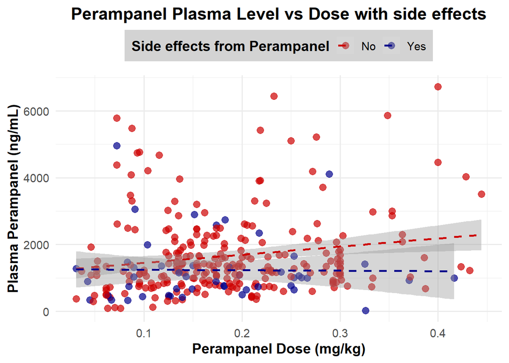

```r
PKPD_JRS_transposed_all$`side effects FIXED` <- as.factor(PKPD_JRS_transposed_all$`side effects (0 = none, 1=something)`)

ggplot(data = PKPD_JRS_transposed_all, aes(x = `mgkg`,
                                       y = `Perampanel blood test value`,
                                       color = `side effects FIXED`)) +
  geom_point(size = 3, alpha = 0.7) +  # Adjust point size and transparency
  #geom_jitter(size = 3, alpha = 0.7, width = 0.3, height = 0, seed = 666) +  # Add jitter to points
  geom_smooth(method = "lm", se = TRUE, linetype = "dashed", size = 1) +  # Add dashed regression lines
  labs(title = "Perampanel Plasma Level vs Dose with side effects",
       x = "Perampanel Dose (mg/kg)",
       y = "Plasma Perampanel (ng/mL)",
       color = "Side effects from Perampanel") +
  theme_minimal(base_size = 14) +  # Use a larger base size for better readability
  scale_color_manual(values = c("0" = "red3", "1" = "blue4"),  # Custom color scheme
                     labels = c("No", "Yes")) +  # Custom labels for the legend
  theme(
    plot.title = element_text(hjust = 0.5, face = "bold"),  # Center and bold the title
    axis.title = element_text(face = "bold"),  # Bold the axis titles
    legend.position = "top",  # Position the legend at the top
    legend.title = element_text(face = "bold"),  # Bold the legend title
    legend.background = element_rect(fill = "lightgray", color = NA),  # Light gray background for legend
    legend.key = element_rect(fill = "white", color = NA)  # White background for legend keys
  )
```

# Table 1 (in manuscript), using file with 1 visit per patient. Making a data table on patient profiles.

```r
# Convert to factors
PKPD_JRS_transposed$`Gender (0=F, 1=M)` <- as.factor(PKPD_JRS_transposed$`Gender (0=F, 1=M)`)
levels(PKPD_JRS_transposed$`Gender (0=F, 1=M)`) <- c("Female", "Male")

PKPD_JRS_transposed$`Beneficial effect on seizures 3 months AFTER perampanel start (0=no, 1=yes) FIXED` <- as.factor(PKPD_JRS_transposed$`Beneficial effect on seizures 3 months AFTER perampanel start (0=no, 1=yes) FIXED`)
levels(PKPD_JRS_transposed$`Beneficial effect on seizures 3 months AFTER perampanel start (0=no, 1=yes) FIXED`) <- c("No", "Yes")

PKPD_JRS_transposed$`side effects (0 = none, 1=something)` <- as.factor(PKPD_JRS_transposed$`side effects (0 = none, 1=something)`)
levels(PKPD_JRS_transposed$`side effects (0 = none, 1=something)`) <- c("No", "Yes")

PKPD_JRS_transposed$`Did the Patient become seizure free on perampanel? (0=no, 1=yes)` <- as.factor(PKPD_JRS_transposed$`Did the Patient become seizure free on perampanel? (0=no, 1=yes)`)
levels(PKPD_JRS_transposed$`Did the Patient become seizure free on perampanel? (0=no, 1=yes)`) <- c("No", "Yes")

PKPD_JRS_transposed$`Is the Patient currently on perampanel treatment? (Y/N). If "No" then go to row 21 (0=No, 1=Yes)` <- as.factor(PKPD_JRS_transposed$`Is the Patient currently on perampanel treatment? (Y/N). If "No" then go to row 21 (0=No, 1=Yes)`)
levels(PKPD_JRS_transposed$`Is the Patient currently on perampanel treatment? (Y/N). If "No" then go to row 21 (0=No, 1=Yes)`) <- c("No", "Yes")

# Apply descriptive labels
table1::label(PKPD_JRS_transposed$`Current age, full years`) <- "Current age (years)"
table1::label(PKPD_JRS_transposed$`Age at start of perampanel (full years)`) <- "Age at start of perampanel (years)"
table1::label(PKPD_JRS_transposed$`Gender (0=F, 1=M)`) <- "Sex"
table1::label(PKPD_JRS_transposed$`Weight at plasma measure`) <- "Weight (kg)"
table1::label(PKPD_JRS_transposed$`side effects (0 = none, 1=something)`) <- "Adverse effects"
table1::label(PKPD_JRS_transposed$`Beneficial effect on seizures 3 months AFTER perampanel start (0=no, 1=yes) FIXED`) <- "Reduced seizure burden 3 months after perampanel start"
table1::label(PKPD_JRS_transposed$`Did the Patient become seizure free on perampanel? (0=no, 1=yes)`) <- "Patient became seizure free on perampanel"
table1::label(PKPD_JRS_transposed$`Is the Patient currently on perampanel treatment? (Y/N). If "No" then go to row 21 (0=No, 1=Yes)`) <- "Patient is currently on perampanel"
table1::label(PKPD_JRS_transposed$`Total duration of perampanel treatment (in total years) (remains to be calculated)`) <- "Total duration of perampanel treatment (years)"
table1::label(PKPD_JRS_transposed$`Seizure type (focal, generalized, both focal+generalized, unknown origin)`) <- "Seizure type"

# Function to render missing values
render_missing <- function(x, ...) c("Missing" = sum(is.na(x)))

# Custom continuous rendering function:
# Show both median [Q1–Q3] and median [min–max] for age and duration,
# only median [Q1–Q3] for others.
my.render.cont <- function(x, ...) {
  lbl <- attr(x, "label")
  q1 <- quantile(x, 0.25, na.rm = TRUE)
  q3 <- quantile(x, 0.75, na.rm = TRUE)
  mn <- min(x, na.rm = TRUE)
  mx <- max(x, na.rm = TRUE)
  med <- median(x, na.rm = TRUE)

  if (lbl %in% c("Age at start of perampanel (years)",
                 "Total duration of perampanel treatment (years)")) {
    c("",
      "Median [Q1–Q3]" = sprintf("%.1f [%.1f–%.1f]", med, q1, q3),
      "Median [min–max]" = sprintf("%.1f [%.1f–%.1f]", med, mn, mx))
  } else {
    c("",
      "Median [Q1–Q3]" = sprintf("%.1f [%.1f–%.1f]", med, q1, q3))
  }
}

# Calculate total number of patients
total_patients <- nrow(PKPD_JRS_transposed[!is.na(PKPD_JRS_transposed$Name), ])

# Create age group variable
PKPD_JRS_transposed$`Age group` <- cut(
  PKPD_JRS_transposed$`Age at start of perampanel (full years)`,
  breaks = c(-Inf, 5, 12, Inf),
  labels = c("<6", "6–12", ">12"),
  right = TRUE
)

table1::label(PKPD_JRS_transposed$`Age group`) <- "Age group (age at start of perampanel)"

# Generate summary table
table_output <- table1(
  ~ `Age at start of perampanel (full years)` +
    `Age group` +
    `Gender (0=F, 1=M)` +
    `Weight at plasma measure` +
    `Seizure type (focal, generalized, both focal+generalized, unknown origin)` +
    `Beneficial effect on seizures 3 months AFTER perampanel start (0=no, 1=yes) FIXED` +
    `Did the Patient become seizure free on perampanel? (0=no, 1=yes)` +
    `side effects (0 = none, 1=something)` +
    `Is the Patient currently on perampanel treatment? (Y/N). If "No" then go to row 21 (0=No, 1=Yes)` +
    `Total duration of perampanel treatment (in total years) (remains to be calculated)`,
  data = PKPD_JRS_transposed,
  render.missing = render_missing,
  render.continuous = my.render.cont,
  overall = "Perampanel",
  topclass = "Rtable1-basic",
  rowlabelhead = "Patient characteristics"
)

table_output
```

| Patient characteristics | Perampanel (N=68) |
| --- | --- |
| Age at start of perampanel (years) |  |
| Median [Q1–Q3] | 10.5 [6.0–14.0] |
| Median [min–max] | 10.5 [1.0–18.0] |
| Age group (age at start of perampanel) |  |
| <6 | 15 (22.1%) |
| 6–12 | 29 (42.6%) |
| >12 | 24 (35.3%) |
| Sex |  |
| Female | 36 (52.9%) |
| Male | 32 (47.1%) |
| Weight (kg) |  |
| Median [Q1–Q3] | 41.3 [25.0–54.1] |
| Seizure type |  |
| Focal | 35 (51.5%) |
| Focal and generalized | 18 (26.5%) |
| Generalized | 15 (22.1%) |
| Reduced seizure burden 3 months after perampanel start |  |
| No | 13 (19.1%) |
| Yes | 55 (80.9%) |
| Patient became seizure free on perampanel |  |
| No | 54 (79.4%) |
| Yes | 14 (20.6%) |
| Adverse effects |  |
| No | 31 (45.6%) |
| Yes | 37 (54.4%) |
| Patient is currently on perampanel |  |
| No | 26 (38.2%) |
| Yes | 42 (61.8%) |
| Total duration of perampanel treatment (years) |  |
| Median [Q1–Q3] | 2.8 [1.0–5.0] |
| Median [min–max] | 2.8 [0.1–12.0] |

# Supplemental Table 1 (in manuscript), medication list with KABLE (including Perampanel).

```r
medication_df <- PKPD_JRS_transposed_all %>%
  select(Name, Medications_correct_to_john_alphabetic) %>%
  separate_rows(Medications_correct_to_john_alphabetic, sep = ",") %>%
  mutate(Medications_correct_to_john_alphabetic = trimws(Medications_correct_to_john_alphabetic))

#Total number of patients
total_patients <- n_distinct(medication_df$Name)

#Medication summary by drug (including perampanel)
medication_summary_incl <- medication_df %>%
  group_by(Medications_correct_to_john_alphabetic) %>%
  summarise(
    `Number of Patients` = n_distinct(Name),
    .groups = 'drop'
  ) %>%
  arrange(desc(`Number of Patients`))

#percentage of patients
medication_summary_incl <- medication_summary_incl %>%
  mutate(
    `Percentage of Patients` = percent(`Number of Patients` / total_patients)
  )

#Number of medications per patient (including perampanel)
medications_per_patient_incl <- medication_df %>%
  group_by(Name) %>%
  summarise(
    Medications_Per_Patient = n_distinct(Medications_correct_to_john_alphabetic)
  )

#statistics for medications per patient (including perampanel)
overall_median_incl <- median(medications_per_patient_incl$Medications_Per_Patient, na.rm = TRUE)
overall_iqr_incl <- quantile(medications_per_patient_incl$Medications_Per_Patient, c(0.25, 0.75), na.rm = TRUE)

# Add only the median [IQR] row (incl. perampanel)
medication_summary_incl <- medication_summary_incl %>%
  add_row(
    Medications_correct_to_john_alphabetic = "Median of medications administered [IQR] (incl. perampanel)",
    `Number of Patients` = NA,
    `Percentage of Patients` = paste0(overall_median_incl, " [", round(overall_iqr_incl[1], 1), " - ", round(overall_iqr_incl[2], 1), "]")
  )

#Final medication summary
medication_summary <- medication_summary_incl %>%
  distinct(Medications_correct_to_john_alphabetic, .keep_all = TRUE)

#Convert 'Number of Patients' to character to handle NA properly for summary row
medication_summary$`Number of Patients` <- as.character(medication_summary$`Number of Patients`)
medication_summary$`Number of Patients`[is.na(medication_summary$`Number of Patients`)] <- ""

# Move the statistical row to the bottom
statistical_rows <- medication_summary %>%
  dplyr::filter(grepl("Median", Medications_correct_to_john_alphabetic))

medication_summary_main <- medication_summary %>%
  dplyr::filter(!grepl("Median", Medications_correct_to_john_alphabetic))

#Combine main summary with the statistical row at the bottom
medication_summary_final <- bind_rows(medication_summary_main, statistical_rows)

#row to bold
rows_to_bold <- which(medication_summary_final$Medications_correct_to_john_alphabetic ==
  "Median of medications administered [IQR] (incl. perampanel)")

#table
medication_summary_final %>%
  kbl(
    caption = "<b>Medications administered to patients</b>",
    col.names = c("Medications", "Number of patients", "Percentage of patients"),
    align = "lcc",
    escape = FALSE
  ) %>%
  kable_classic(full_width = FALSE, html_font = "<Calibri>") %>%
  row_spec(0, bold = TRUE) %>%
  row_spec(0, extra_css = "padding-top:7px;padding-bottom:7px;") %>%
  row_spec(rows_to_bold, bold = TRUE)
```

**Medications administered to patients**

| Medications | Number of patients | Percentage of patients |
| --- | --- | --- |
| Perampanel | 68 | 100.0% |
| Clobazam | 21 | 30.9% |
| Zonisamide | 18 | 26.5% |
| Eslicarbazepine | 17 | 25.0% |
| Lacosamide | 15 | 22.1% |
| Levetiracetam | 15 | 22.1% |
| Cannabidiol | 14 | 20.6% |
| Valproate | 12 | 17.6% |
| Brivaracetam | 9 | 13.2% |
| Topiramate | 9 | 13.2% |
| Lamotrigine | 6 | 8.8% |
| Rufinamide | 6 | 8.8% |
| Carbamazepine | 5 | 7.4% |
| Ethosuximide | 5 | 7.4% |
| Vigabatrin | 4 | 5.9% |
| Gabapentin | 3 | 4.4% |
| Oxcarbazepine | 3 | 4.4% |
| Clonazepam | 2 | 2.9% |
| Sultiame | 2 | 2.9% |
| Acetazolamide | 1 | 1.5% |
| Potassium bromide | 1 | 1.5% |
| Pregabalin | 1 | 1.5% |
| Risperidone | 1 | 1.5% |
| Median of medications administered [IQR] (incl. perampanel) |  | 3 [2 - 4] |

```r
medication_summary_final
```

```
## # A tibble: 24 × 3
##    Medications_correct_to_john_alp…¹ `Number of Patients` Percentage of Patien…²
##    <chr>                             <chr>                <chr>
##  1 Perampanel                        68                   100.0%
##  2 Clobazam                          21                   30.9%
##  3 Zonisamide                        18                   26.5%
##  4 Eslicarbazepine                   17                   25.0%
##  5 Lacosamide                        15                   22.1%
##  6 Levetiracetam                     15                   22.1%
##  7 Cannabidiol                       14                   20.6%
##  8 Valproate                         12                   17.6%
##  9 Brivaracetam                      9                    13.2%
## 10 Topiramate                        9                    13.2%
## # ℹ 14 more rows
## # ℹ abbreviated names: ¹Medications_correct_to_john_alphabetic,
## #   ²`Percentage of Patients`
```

# Supplemental Table 2 (in manuscript), 10 most frequently coadministered medications per patient.

```r
#Combination per patient per visit
combination_df <- PKPD_JRS_transposed_all %>%
  select(
    Name,
    Visit_number,
    beneficial_raw = `Beneficial effect on seizures 3 months AFTER perampanel start (0=no, 1=yes) FIXED`,
    side_effect_raw = `new side effects (0 = none, 1=something)`,
    Medications_correct_to_john_alphabetic
  ) %>%
  separate_rows(Medications_correct_to_john_alphabetic, sep = ",") %>%
  mutate(Medications_correct_to_john_alphabetic = trimws(Medications_correct_to_john_alphabetic)) %>%
  group_by(Name, Visit_number) %>%
  summarise(
    Combination = paste(
      c("Perampanel", sort(setdiff(unique(Medications_correct_to_john_alphabetic), "Perampanel"))),
      collapse = ", "
    ),
    reduced_seizure_burden = max(beneficial_raw, na.rm = TRUE),
    adverse_effects = max(side_effect_raw, na.rm = TRUE),
    .groups = 'drop'
  )

#Patient-level combinations (collapse across visits)
patient_combination <- combination_df %>%
  group_by(Name, Combination) %>%
  summarise(
    reduced_seizure_burden = ifelse(all(is.na(reduced_seizure_burden)), NA, max(reduced_seizure_burden, na.rm = TRUE)),
    adverse_effects = ifelse(all(is.na(adverse_effects)), NA, max(adverse_effects, na.rm = TRUE)),
    .groups = 'drop'
  )

N_total_patients <- patient_combination %>%
  distinct(Name) %>%
  nrow()  # all perampanel patients (mono + combo)

N_combo_patients <- patient_combination %>%
  filter(Combination != "Perampanel") %>%
  distinct(Name) %>%
  nrow()  # only patients with combos

# summary table (only combos)
summary_table <- patient_combination %>%
  filter(Combination != "Perampanel") %>%
  group_by(Combination) %>%
  summarise(
    `Number of patients` = n(),
    `Reduced seizure burden` = sum(reduced_seizure_burden, na.rm = TRUE),
    `Adverse effects` = sum(adverse_effects, na.rm = TRUE),
    .groups = 'drop'
  ) %>%
  mutate(
    `% of patients with reduced seizure burden` = paste0(round((`Reduced seizure burden` / `Number of patients`) * 100, 1), "%"),
    `% of patients with adverse effects` = paste0(round((`Adverse effects` / `Number of patients`) * 100, 1), "%")
  ) %>%
  arrange(desc(`Reduced seizure burden`)) %>%
  slice_head(n = 10)

#table
summary_table %>%
  kbl(
    caption = paste0(
      "<b>First 10 most frequent co-medications administered per patient (with higher reduced seizure burden first)</b> ",
      "(N = ", N_combo_patients, " patients out of ", N_total_patients, " total)"
    ),
    align = "lccccc",
    escape = FALSE
  ) %>%
  kable_classic(full_width = FALSE, html_font = "Calibri") %>%
  column_spec(1:ncol(summary_table), extra_css = "white-space: nowrap; background-color:white;") %>%
  row_spec(0, bold = TRUE, extra_css = "padding-top:7px; padding-bottom:7px; background-color:white;")
```

**First 10 most frequent co-medications administered per patient (with higher reduced seizure burden first)** (N = 66 patients out of 68 total)

| Combination | Number of patients | Reduced seizure burden | Adverse effects | % of patients with reduced seizure burden | % of patients with adverse effects |
| --- | --- | --- | --- | --- | --- |
| Perampanel, Eslicarbazepine | 10 | 9 | 5 | 90% | 50% |
| Perampanel, Lacosamide | 5 | 5 | 2 | 100% | 40% |
| Perampanel, Zonisamide | 8 | 5 | 1 | 62.5% | 12.5% |
| Perampanel, Valproate | 3 | 3 | 1 | 100% | 33.3% |
| Perampanel, Brivaracetam, Clobazam | 2 | 2 | 1 | 100% | 50% |
| Perampanel, Clobazam, Eslicarbazepine | 2 | 2 | 2 | 100% | 100% |
| Perampanel, Lamotrigine, Zonisamide | 2 | 2 | 2 | 100% | 100% |
| Perampanel, Levetiracetam | 4 | 2 | 3 | 50% | 75% |
| Perampanel, Levetiracetam, Topiramate | 2 | 2 | 2 | 100% | 100% |
| Perampanel, Oxcarbazepine | 2 | 2 | 1 | 100% | 50% |

# Supplemental Table 3 (in manuscript), adverse effects.

```r
#Define symptom groups
side_effect_groups <- list(
  "None" = c("none"),
  "Central nervous system" = c("fatigue", "dizziness", "reduced cognitive performance", "increased seizures","memory difficulties"),

  "Psychobehavioral" = c("aggressivity", "irritability",
                         "depression / sadness", "mood swings", "restlessness"),

  "Gastrointestinal" = c("weight gain / increased appetite", "abdominal pain", "loose stool", "nausea"),
  "Other" = c("restless sleep")
)

#Map symptoms to group
symptom_to_group <- unlist(lapply(names(side_effect_groups), function(group) {
  setNames(rep(group, length(side_effect_groups[[group]])), side_effect_groups[[group]])
}))

#medication_df from patient data
medication_df <- PKPD_JRS_transposed_all %>%
  select(Name, `side effects per patient`) %>%
  filter(!is.na(`side effects per patient`)) %>%
  separate_rows(`side effects per patient`, sep = ",") %>%
  mutate(symptom = tolower(trimws(`side effects per patient`))) %>%
  filter(symptom %in% names(symptom_to_group)) %>%
  mutate(
    Category = symptom_to_group[symptom],
    Symptom = str_to_sentence(symptom)
  )

# Total number of patients
total_patients <- n_distinct(PKPD_JRS_transposed_all$Name)

#Count symptoms per category
symptom_summary <- medication_df %>%
  group_by(Category, Symptom) %>%
  summarise(
    Patients = n_distinct(Name),
    .groups = "drop"
  ) %>%
  mutate(Percentage = percent(Patients / total_patients)) %>%
  arrange(match(Category, names(side_effect_groups)), Category, desc(Patients))

#Add bold category only on first row of each group
symptom_summary <- symptom_summary %>%
  group_by(Category) %>%
  mutate(
    Category_display = ifelse(row_number() == 1, paste0("<strong>", Category, "</strong>"), "")
  ) %>%
  ungroup()

#Calculate average side effect groups per patient
average_side_effects <- medication_df %>%
  group_by(Name) %>%
  summarise(UniqueGroups = n_distinct(Category)) %>%
  summarise(Average = mean(UniqueGroups)) %>%
  pull(Average)

#final table
final_table <- symptom_summary %>%
  select(Category = Category_display, Symptom, Patients, Percentage) %>%
  mutate(across(everything(), as.character)) %>%
  add_row(
    Category = "<strong>Average number of adverse effect groups per patient</strong>",
    Symptom = "",
    Patients = "",
    Percentage = as.character(round(average_side_effects, 2))
  )

#Render styled kable table
manual_rows_to_space <- c(1, 6, 11, 15, 16)

final_table %>%
  kbl(
    format = "html",
    col.names = c("Category", "Adverse effects", "Number of patients", "Percentage of patients"),
    caption = paste0("<b>Patients experiencing specific adverse effects</b> (N = ", total_patients, ")"),
    align = "lccc",
    escape = FALSE
  ) %>%
  kable_classic(full_width = FALSE, html_font = "Calibri") %>%
  row_spec(0, bold = TRUE, extra_css = "padding-top:7px; padding-bottom:7px;") %>%
  row_spec(manual_rows_to_space, extra_css = "padding-bottom:12px;")
```

**Patients experiencing specific adverse effects** (N = 68)

| Category | Adverse effects | Number of patients | Percentage of patients |
| --- | --- | --- | --- |
| **None** | None | 26 | 38.2% |
| **Central nervous system** | Fatigue | 22 | 32.4% |
|  | Dizziness | 13 | 19.1% |
|  | Increased seizures | 2 | 2.9% |
|  | Reduced cognitive performance | 2 | 2.9% |
|  | Memory difficulties | 1 | 1.5% |
| **Psychobehavioral** | Aggressivity | 9 | 13.2% |
|  | Irritability | 4 | 5.9% |
|  | Depression / sadness | 2 | 2.9% |
|  | Mood swings | 1 | 1.5% |
|  | Restlessness | 1 | 1.5% |
| **Gastrointestinal** | Weight gain / increased appetite | 4 | 5.9% |
|  | Abdominal pain | 1 | 1.5% |
|  | Loose stool | 1 | 1.5% |
|  | Nausea | 1 | 1.5% |
| **Other** | Restless sleep | 2 | 2.9% |
| **Average number of adverse effect groups per patient** |  |  | 1.15 |

# Calculations.

```r
# Reference range
ref_low <- 250
ref_high <- 2850

df <- PKPD_JRS_transposed_all %>%
  mutate(
    Perampanel_val = as.numeric(`Perampanel blood test value`),
    Date_Perampanel = as.Date(`Date of Perampanel`, format = "%d/%m/%Y")
  ) %>%
  filter(!is.na(Perampanel_val))

# Count measurements below/above reference range (all measurements)
range_counts <- df %>%
  summarise(
    below_n = sum(Perampanel_val < ref_low, na.rm = TRUE),
    below_patients = n_distinct(Name[Perampanel_val < ref_low]),
    above_n = sum(Perampanel_val > ref_high, na.rm = TRUE),
    above_patients = n_distinct(Name[Perampanel_val > ref_high])
  )

results <- list(
  measurements_out_of_range = range_counts
)

results
```

```
## $measurements_out_of_range
## # A tibble: 1 × 4
##   below_n below_patients above_n above_patients
##     <int>          <int>   <int>          <int>
## 1       5              5      38             14
```

# Basic stats using GLM and logistic regression

## stats on Did the Patient become seizure free on perampanel?

```r
# Fit the logistic regression model
logistic_model <- glm(`Did the Patient become seizure free on perampanel? (0=no, 1=yes)` ~ `Perampanel blood test value` + `Weight at plasma measure` + `Gender (0=F, 1=M)` + `Age at start of perampanel (full years)`  ,
                      data = PKPD_JRS_transposed, family = binomial)

# Display the summary of the model
summary(logistic_model)
```

```
##
## Call:
## glm(formula = `Did the Patient become seizure free on perampanel? (0=no, 1=yes)` ~
##     `Perampanel blood test value` + `Weight at plasma measure` +
##         `Gender (0=F, 1=M)` + `Age at start of perampanel (full years)`,
##     family = binomial, data = PKPD_JRS_transposed)
##
## Coefficients:
##                                             Estimate Std. Error z value
## (Intercept)                               -0.9337471  1.0105512  -0.924
## `Perampanel blood test value`             -0.0003498  0.0003638  -0.961
## `Weight at plasma measure`                -0.0154774  0.0297100  -0.521
## `Gender (0=F, 1=M)`Male                    0.9261620  0.6587541   1.406
## `Age at start of perampanel (full years)`  0.0182113  0.1270660   0.143
##                                           Pr(>|z|)
## (Intercept)                                  0.355
## `Perampanel blood test value`                0.336
## `Weight at plasma measure`                   0.602
## `Gender (0=F, 1=M)`Male                      0.160
## `Age at start of perampanel (full years)`    0.886
##
## (Dispersion parameter for binomial family taken to be 1)
##
##     Null deviance: 69.149  on 67  degrees of freedom
## Residual deviance: 65.212  on 63  degrees of freedom
## AIC: 75.212
##
## Number of Fisher Scoring iterations: 5
```

```r
# Calculate the odds ratios and 95% confidence intervals
exp_coef <- exp(coef(logistic_model))  # Odds ratios
conf_int <- exp(confint(logistic_model))  # Confidence intervals
# Combine odds ratios and confidence intervals into a data frame
OR_results <- data.frame(Odds_Ratio = exp_coef, Lower_CI = conf_int[,1], Upper_CI = conf_int[,2])

# Display the results
OR_results
```

```
##                                           Odds_Ratio   Lower_CI Upper_CI
## (Intercept)                                0.3930780 0.05036256 2.824748
## `Perampanel blood test value`              0.9996503 0.99878880 1.000245
## `Weight at plasma measure`                 0.9846418 0.92588750 1.042691
## `Gender (0=F, 1=M)`Male                    2.5248005 0.71930041 9.959287
## `Age at start of perampanel (full years)`  1.0183781 0.78801526 1.308405
```

## stats on Beneficial effect on seizures 3 months AFTER perampanel start (0=no, 1=yes) FIXED.

```r
# Fit the logistic regression model
logistic_model <- glm(`Beneficial effect on seizures 3 months AFTER perampanel start (0=no, 1=yes) FIXED` ~ `Perampanel blood test value` + `Weight at plasma measure` + `Gender (0=F, 1=M)` + `Age at start of perampanel (full years)`,
                      data = PKPD_JRS_transposed, family = binomial)

# Display the summary of the model
summary(logistic_model)
```

```
##
## Call:
## glm(formula = `Beneficial effect on seizures 3 months AFTER perampanel start (0=no, 1=yes) FIXED` ~
##     `Perampanel blood test value` + `Weight at plasma measure` +
##         `Gender (0=F, 1=M)` + `Age at start of perampanel (full years)`,
##     family = binomial, data = PKPD_JRS_transposed)
##
## Coefficients:
##                                             Estimate Std. Error z value
## (Intercept)                                2.1331743  0.9975234   2.138
## `Perampanel blood test value`             -0.0001018  0.0002682  -0.379
## `Weight at plasma measure`                -0.0383054  0.0267919  -1.430
## `Gender (0=F, 1=M)`Male                    0.1704953  0.6442807   0.265
## `Age at start of perampanel (full years)`  0.1060630  0.1237407   0.857
##                                           Pr(>|z|)
## (Intercept)                                 0.0325 *
## `Perampanel blood test value`               0.7044
## `Weight at plasma measure`                  0.1528
## `Gender (0=F, 1=M)`Male                     0.7913
## `Age at start of perampanel (full years)`   0.3914
## ---
## Signif. codes:  0 '***' 0.001 '**' 0.01 '*' 0.05 '.' 0.1 ' ' 1
##
## (Dispersion parameter for binomial family taken to be 1)
##
##     Null deviance: 66.358  on 67  degrees of freedom
## Residual deviance: 63.555  on 63  degrees of freedom
## AIC: 73.555
##
## Number of Fisher Scoring iterations: 4
```

```r
# Calculate the odds ratios and 95% confidence intervals
exp_coef <- exp(coef(logistic_model))  # Odds ratios
conf_int <- exp(confint(logistic_model))  # Confidence intervals
# Combine odds ratios and confidence intervals into a data frame
OR_results <- data.frame(Odds_Ratio = exp_coef, Lower_CI = conf_int[,1], Upper_CI = conf_int[,2])

# Display the results
OR_results
```

```
##                                           Odds_Ratio  Lower_CI  Upper_CI
## (Intercept)                                8.4416206 1.3111318 69.575238
## `Perampanel blood test value`              0.9998983 0.9993969  1.000490
## `Weight at plasma measure`                 0.9624190 0.9105742  1.013315
## `Gender (0=F, 1=M)`Male                    1.1858921 0.3343165  4.357660
## `Age at start of perampanel (full years)`  1.1118919 0.8791701  1.440640
```

## stats on side effects FIXED.

```r
# Fit the logistic regression model
logistic_model <- glm(`side effects FIXED` ~ `Perampanel blood test value` + `Weight at plasma measure` + `Gender (0=F, 1=M)` + `Age at start of perampanel (full years)`,
                      data = PKPD_JRS_transposed, family = binomial)

# Display the summary of the model
summary(logistic_model)
```

```
##
## Call:
## glm(formula = `side effects FIXED` ~ `Perampanel blood test value` +
##     `Weight at plasma measure` + `Gender (0=F, 1=M)` + `Age at start of perampanel (full years)`,
##     family = binomial, data = PKPD_JRS_transposed)
##
## Coefficients:
##                                             Estimate Std. Error z value
## (Intercept)                                0.5471353  0.7907390   0.692
## `Perampanel blood test value`             -0.0002475  0.0002382  -1.039
## `Weight at plasma measure`                -0.0305599  0.0228309  -1.339
## `Gender (0=F, 1=M)`Male                   -0.1823183  0.5181287  -0.352
## `Age at start of perampanel (full years)`  0.1365029  0.0995862   1.371
##                                           Pr(>|z|)
## (Intercept)                                  0.489
## `Perampanel blood test value`                0.299
## `Weight at plasma measure`                   0.181
## `Gender (0=F, 1=M)`Male                      0.725
## `Age at start of perampanel (full years)`    0.170
##
## (Dispersion parameter for binomial family taken to be 1)
##
##     Null deviance: 93.738  on 67  degrees of freedom
## Residual deviance: 88.973  on 63  degrees of freedom
## AIC: 98.973
##
## Number of Fisher Scoring iterations: 4
```

```r
# Calculate the odds ratios and 95% confidence intervals
exp_coef <- exp(coef(logistic_model))  # Odds ratios
conf_int <- exp(confint(logistic_model))  # Confidence intervals
# Combine odds ratios and confidence intervals into a data frame
OR_results <- data.frame(Odds_Ratio = exp_coef, Lower_CI = conf_int[,1], Upper_CI = conf_int[,2])

# Display the results
OR_results
```

```
##                                           Odds_Ratio  Lower_CI Upper_CI
## (Intercept)                                1.7282948 0.3717614 8.555309
## `Perampanel blood test value`              0.9997525 0.9992375 1.000200
## `Weight at plasma measure`                 0.9699023 0.9253943 1.013376
## `Gender (0=F, 1=M)`Male                    0.8333361 0.3000421 2.318814
## `Age at start of perampanel (full years)`  1.1462582 0.9475720 1.406836
```

# Stats for analyzing with the repeated measures.

## Beneficial effect on seizures 3 months AFTER perampanel start (0=no, 1=yes) FIXED.

```r
# Ensure 'Name' and 'Visit_number' are factors
PKPD_JRS_transposed_all$Name <- as.factor(PKPD_JRS_transposed_all$Name)
PKPD_JRS_transposed_all$Visit_number <- as.factor(PKPD_JRS_transposed_all$Visit_number)

visit_counts <- PKPD_JRS_transposed_all %>%
  group_by(Visit_number) %>%
  tally()

# # Filter out 'Visit_number's greater than 10 and count occurrences
PKPD_JRS_filtered <- PKPD_JRS_transposed_all %>%
  filter(as.numeric(Visit_number) <= 10) %>%  # Remove visits greater than 10
  group_by(Visit_number) %>%
  tally()

# Further filter to remove 'Visit_number's with only one observation
PKPD_JRS_cleaned <- PKPD_JRS_transposed_all %>%
  filter(as.numeric(Visit_number) <= 10) %>%  # Keep only visits <= 10
  filter(Visit_number %in% visit_counts$Visit_number[visit_counts$n > 1])

### Hmmm this is tricky to remove, because it deletes most rows.
#PKPD_JRS_cleaned_duration <- PKPD_JRS_cleaned %>%
#  filter(as.numeric(`Total duration of perampanel treatment (in total years) (remains to be calculated)`) <= 5)

# Fit the mixed-effects logistic regression model
# Random effects for Name and Visit_number (nested within Name)
mixed_logistic_model <- glmer(`Beneficial effect (0=no, 1=yes) FIXED` ~ `Perampanel blood test value` +  `Weight at plasma measure` + (1 | Visit_number),
                              data = PKPD_JRS_cleaned, family = binomial)
```

```
## boundary (singular) fit: see help('isSingular')
```

```r
# Display the summary of the model
summary(mixed_logistic_model)
```

```
## Generalized linear mixed model fit by maximum likelihood (Laplace
##   Approximation) [glmerMod]
##  Family: binomial  ( logit )
## Formula:
## `Beneficial effect (0=no, 1=yes) FIXED` ~ `Perampanel blood test value` +
##     `Weight at plasma measure` + (1 | Visit_number)
##    Data: PKPD_JRS_cleaned
##
##       AIC       BIC    logLik -2*log(L)  df.resid
##     279.2     293.9    -135.6     271.2       284
##
## Scaled residuals:
##     Min      1Q  Median      3Q     Max
## -3.1766  0.3397  0.4226  0.5152  0.7383
##
## Random effects:
##  Groups       Name        Variance Std.Dev.
##  Visit_number (Intercept) 0        0
## Number of obs: 288, groups:  Visit_number, 10
##
## Fixed effects:
##                                 Estimate Std. Error z value Pr(>|z|)
## (Intercept)                    2.7378408  0.4298095   6.370 1.89e-10 ***
## `Perampanel blood test value` -0.0001759  0.0001183  -1.486  0.13715
## `Weight at plasma measure`    -0.0219878  0.0067409  -3.262  0.00111 **
## ---
## Signif. codes:  0 '***' 0.001 '**' 0.01 '*' 0.05 '.' 0.1 ' ' 1
##
## Correlation of Fixed Effects:
##             (Intr) `Pbtv`
## `Prmpnbtvl` -0.527
## `Wghtapmsr` -0.809  0.073
## fit warnings:
## Some predictor variables are on very different scales: consider rescaling
## optimizer (Nelder_Mead) convergence code: 0 (OK)
## boundary (singular) fit: see help('isSingular')
```

```r
# Calculate odds ratios and 95% confidence intervals
exp_coef <- exp(fixef(mixed_logistic_model))  # Odds ratios for fixed effects
conf_int <- exp(confint(mixed_logistic_model, parm = "beta_", method = "Wald"))  # Confidence intervals

# Combine odds ratios and confidence intervals into a data frame
OR_results <- data.frame(Odds_Ratio = exp_coef, Lower_CI = conf_int[,1], Upper_CI = conf_int[,2])

# Display the results
OR_results
```

```
##                               Odds_Ratio  Lower_CI   Upper_CI
## (Intercept)                   15.4535817 6.6554075 35.8825794
## `Perampanel blood test value`  0.9998241 0.9995922  1.0000560
## `Weight at plasma measure`     0.9782522 0.9654126  0.9912625
```

## Did the Patient become seizure free on perampanel? (0=no, 1=yes) including only visits 1 to 10.

```r
# Ensure 'Name' and 'Visit_number' are factors
PKPD_JRS_transposed_all$Name <- as.factor(PKPD_JRS_transposed_all$Name)
PKPD_JRS_transposed_all$Visit_number <- as.factor(PKPD_JRS_transposed_all$Visit_number)

visit_counts <- PKPD_JRS_transposed_all %>%
  group_by(Visit_number) %>%
  tally()

# # Filter out 'Visit_number's greater than 10 and count occurrences
PKPD_JRS_filtered <- PKPD_JRS_transposed_all %>%
  filter(as.numeric(Visit_number) <= 10) %>%  # Remove visits greater than 10
  group_by(Visit_number) %>%
  tally()

# Further filter to remove 'Visit_number's with only one observation
PKPD_JRS_cleaned <- PKPD_JRS_transposed_all %>%
  filter(as.numeric(Visit_number) <= 10) %>%  # Keep only visits <= 10
  filter(Visit_number %in% visit_counts$Visit_number[visit_counts$n > 1])

# Fit the mixed-effects logistic regression model
# Random effects for Name and Visit_number (nested within Name)
mixed_logistic_model <- glmer(`Did the Patient  become seizure free on perampanel? (0=no, 1=yes)` ~ `Perampanel blood test value` +  `Weight at plasma measure` + (1 | Visit_number),
                              data = PKPD_JRS_cleaned, family = binomial)
```

```
## boundary (singular) fit: see help('isSingular')
```

```r
# Display the summary of the model
summary(mixed_logistic_model)
```

```
## Generalized linear mixed model fit by maximum likelihood (Laplace
##   Approximation) [glmerMod]
##  Family: binomial  ( logit )
## Formula: `Did the Patient  become seizure free on perampanel? (0=no, 1=yes)` ~
##     `Perampanel blood test value` + `Weight at plasma measure` +
##         (1 | Visit_number)
##    Data: PKPD_JRS_cleaned
##
##       AIC       BIC    logLik -2*log(L)  df.resid
##     272.3     286.9    -132.1     264.3       284
##
## Scaled residuals:
##     Min      1Q  Median      3Q     Max
## -0.7565 -0.5271 -0.4344 -0.2741  3.0296
##
## Random effects:
##  Groups       Name        Variance Std.Dev.
##  Visit_number (Intercept) 0        0
## Number of obs: 288, groups:  Visit_number, 10
##
## Fixed effects:
##                                 Estimate Std. Error z value Pr(>|z|)
## (Intercept)                   -0.2544400  0.4211542  -0.604   0.5457
## `Perampanel blood test value` -0.0003991  0.0001782  -2.240   0.0251 *
## `Weight at plasma measure`    -0.0160640  0.0078982  -2.034   0.0420 *
## ---
## Signif. codes:  0 '***' 0.001 '**' 0.01 '*' 0.05 '.' 0.1 ' ' 1
##
## Correlation of Fixed Effects:
##             (Intr) `Pbtv`
## `Prmpnbtvl` -0.563
## `Wghtapmsr` -0.751  0.021
## fit warnings:
## Some predictor variables are on very different scales: consider rescaling
## optimizer (Nelder_Mead) convergence code: 0 (OK)
## boundary (singular) fit: see help('isSingular')
```

```r
# Calculate odds ratios and 95% confidence intervals
exp_coef <- exp(fixef(mixed_logistic_model))  # Odds ratios for fixed effects
conf_int <- exp(confint(mixed_logistic_model, parm = "beta_", method = "Wald"))  # Confidence intervals

# Combine odds ratios and confidence intervals into a data frame
OR_results <- data.frame(Odds_Ratio = exp_coef, Lower_CI = conf_int[,1], Upper_CI = conf_int[,2])

# Display the results
OR_results
```

```
##                               Odds_Ratio  Lower_CI  Upper_CI
## (Intercept)                    0.7753506 0.3396339 1.7700486
## `Perampanel blood test value`  0.9996010 0.9992520 0.9999501
## `Weight at plasma measure`     0.9840644 0.9689482 0.9994163
```

# Stats for analyzing with the repeated measures.

```r
# Ensure 'Name' and 'Visit_number' are factors
PKPD_JRS_transposed_all$Name <- as.factor(PKPD_JRS_transposed_all$Name)
PKPD_JRS_transposed_all$Visit_number <- as.factor(PKPD_JRS_transposed_all$Visit_number)

visit_counts <- PKPD_JRS_transposed_all %>%
  group_by(Visit_number) %>%
  tally()

# # Filter out 'Visit_number's greater than 10 and count occurrences
PKPD_JRS_filtered <- PKPD_JRS_transposed_all %>%
  filter(as.numeric(Visit_number) <= 10) %>%  # Remove visits greater than 10
  group_by(Visit_number) %>%
  tally()

# Further filter to remove 'Visit_number's with only one observation
PKPD_JRS_cleaned <- PKPD_JRS_transposed_all %>%
  filter(as.numeric(Visit_number) <= 10) %>%  # Keep only visits <= 10
  filter(Visit_number %in% visit_counts$Visit_number[visit_counts$n > 1])

# Fit the mixed-effects logistic regression model
# Random effects for Name and Visit_number (nested within Name)
mixed_logistic_model <- glmer(`Beneficial effect on seizures 3 months AFTER perampanel start (0=no, 1=yes) FIXED` ~ `Perampanel blood test value` +  `Weight at plasma measure` + (1 | Visit_number),
                              data = PKPD_JRS_cleaned, family = binomial)
```

```
## boundary (singular) fit: see help('isSingular')
```

```r
# Display the summary of the model
summary(mixed_logistic_model)
```

```
## Generalized linear mixed model fit by maximum likelihood (Laplace
##   Approximation) [glmerMod]
##  Family: binomial  ( logit )
## Formula:
## `Beneficial effect on seizures 3 months AFTER perampanel start (0=no, 1=yes) FIXED` ~
##     `Perampanel blood test value` + `Weight at plasma measure` +
##         (1 | Visit_number)
##    Data: PKPD_JRS_cleaned
##
##       AIC       BIC    logLik -2*log(L)  df.resid
##     279.2     293.9    -135.6     271.2       284
##
## Scaled residuals:
##     Min      1Q  Median      3Q     Max
## -3.1766  0.3397  0.4226  0.5152  0.7383
##
## Random effects:
##  Groups       Name        Variance Std.Dev.
##  Visit_number (Intercept) 0        0
## Number of obs: 288, groups:  Visit_number, 10
##
## Fixed effects:
##                                 Estimate Std. Error z value Pr(>|z|)
## (Intercept)                    2.7378408  0.4298095   6.370 1.89e-10 ***
## `Perampanel blood test value` -0.0001759  0.0001183  -1.486  0.13715
## `Weight at plasma measure`    -0.0219878  0.0067409  -3.262  0.00111 **
## ---
## Signif. codes:  0 '***' 0.001 '**' 0.01 '*' 0.05 '.' 0.1 ' ' 1
##
## Correlation of Fixed Effects:
##             (Intr) `Pbtv`
## `Prmpnbtvl` -0.527
## `Wghtapmsr` -0.809  0.073
## fit warnings:
## Some predictor variables are on very different scales: consider rescaling
## optimizer (Nelder_Mead) convergence code: 0 (OK)
## boundary (singular) fit: see help('isSingular')
```

```r
# Calculate odds ratios and 95% confidence intervals
exp_coef <- exp(fixef(mixed_logistic_model))  # Odds ratios for fixed effects
conf_int <- exp(confint(mixed_logistic_model, parm = "beta_", method = "Wald"))  # Confidence intervals

# Combine odds ratios and confidence intervals into a data frame
OR_results <- data.frame(Odds_Ratio = exp_coef, Lower_CI = conf_int[,1], Upper_CI = conf_int[,2])

# Display the results
OR_results
```

```
##                               Odds_Ratio  Lower_CI   Upper_CI
## (Intercept)                   15.4535817 6.6554075 35.8825794
## `Perampanel blood test value`  0.9998241 0.9995922  1.0000560
## `Weight at plasma measure`     0.9782522 0.9654126  0.9912625
```

# Draft of sankey diagram

## Table to get the numbers for the sankey diagram, can be changed to match what to plot.

```r
PKPD_JRS_transposed1 <- PKPD_JRS_transposed_all %>%
  filter(as.numeric(Visit_number) <= 1)


table1(~ as.factor(`Beneficial effect on seizures 3 months AFTER perampanel start (0=no, 1=yes) FIXED`) + `Did the Patient become seizure free on perampanel? (0=no, 1=yes)` + `Seizure type` |
         `side effects FIXED`,
       data = PKPD_JRS_transposed1,
       render.missing = render_missing)
```

|  | 0 (N=31) | 1 (N=37) | Overall (N=68) |
| --- | --- | --- | --- |
| as.factor(`Beneficial effect on seizures 3 months AFTER perampanel start (0=no, 1=yes) FIXED`) |  |  |  |
| 0 | 6 (19.4%) | 7 (18.9%) | 13 (19.1%) |
| 1 | 25 (80.6%) | 30 (81.1%) | 55 (80.9%) |
| Did the Patient become seizure free on perampanel? (0=no, 1=yes) |  |  |  |
| 0 | 27 (87.1%) | 27 (73.0%) | 54 (79.4%) |
| 1 | 4 (12.9%) | 10 (27.0%) | 14 (20.6%) |
| Seizure type |  |  |  |
| Focal | 14 (45.2%) | 21 (56.8%) | 35 (51.5%) |
| Focal and generalized | 8 (25.8%) | 10 (27.0%) | 18 (26.5%) |
| Generalized | 9 (29.0%) | 6 (16.2%) | 15 (22.1%) |

## Table to get the numbers for the sankey diagram, can be changed to match what to plot.

```r
table1(~ as.factor(`Beneficial effect on seizures 3 months AFTER perampanel start (0=no, 1=yes) FIXED`)   |
         `Did the Patient become seizure free on perampanel? (0=no, 1=yes)`,
       data = PKPD_JRS_transposed1,
       render.missing = render_missing)
```

|  | 0 (N=54) | 1 (N=14) | Overall (N=68) |
| --- | --- | --- | --- |
| as.factor(`Beneficial effect on seizures 3 months AFTER perampanel start (0=no, 1=yes) FIXED`) |  |  |  |
| 0 | 13 (24.1%) | 0 (0%) | 13 (19.1%) |
| 1 | 41 (75.9%) | 14 (100%) | 55 (80.9%) |

# Figure 1 (in manuscript), Sankey diagram.

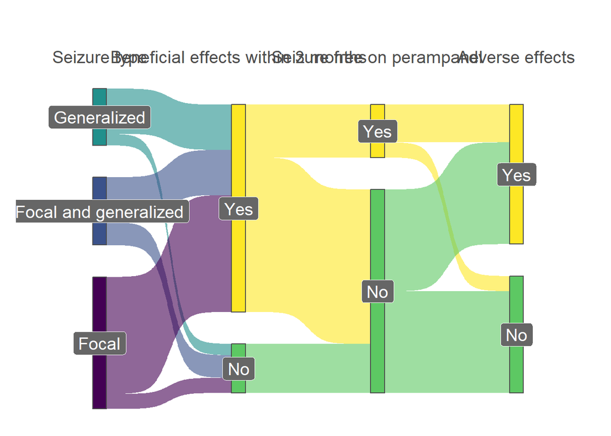

```r
PKPD_JRS_transposed1$`Beneficial effects within 3 months` <- PKPD_JRS_transposed1$`Beneficial effect on seizures 3 months AFTER perampanel start (0=no, 1=yes) FIXED`
PKPD_JRS_transposed1$`Beneficial effects within 3 months` <- ifelse(PKPD_JRS_transposed1$`Beneficial effects within 3 months` == 1, "Yes", "No")

PKPD_JRS_transposed1$`Seizure free on perampanel` <- PKPD_JRS_transposed1$`Did the Patient become seizure free on perampanel? (0=no, 1=yes)`
PKPD_JRS_transposed1$`Seizure free on perampanel` <- ifelse(PKPD_JRS_transposed1$`Seizure free on perampanel` == 1, "Yes", "No")

# Renamed here
PKPD_JRS_transposed1$`Adverse effects` <- PKPD_JRS_transposed1$`side effects FIXED`
PKPD_JRS_transposed1$`Adverse effects` <- ifelse(PKPD_JRS_transposed1$`Adverse effects` == 1, "Yes", "No")

df <- PKPD_JRS_transposed1 %>%
  make_long(`Seizure type`, `Beneficial effects within 3 months`, `Seizure free on perampanel`, `Adverse effects`)

ggplot(df, aes(x = x, next_x = next_x, node = node, next_node = next_node, fill = factor(node), label = node)) +
  geom_sankey(flow.alpha = .6, node.color = "gray30") +
  geom_sankey_label(size = 5, color = "white", fill = "gray40") +
  scale_fill_viridis_d(drop = FALSE) +
  theme_sankey(base_size = 18) +
  labs(x = NULL) +
  scale_x_discrete(position = "top") +
  theme(legend.position = "none",
        plot.title = element_text(hjust = .5)) +
  ggtitle("")
```

# stats on Beneficial effect on seizures 3 months AFTER perampanel start (0=no, 1=yes) FIXED. Adding seizure type here. Remember this is only the first visit, as it labels the beneficial effect at 3 months.

```r
PKPD_JRS_transposed_duration <- PKPD_JRS_transposed1 %>%
  filter(as.numeric(`Total duration of perampanel treatment (in total years) (remains to be calculated)`) <= 5)


# Set the baseline level for Seizure type
PKPD_JRS_transposed1$`Seizure type` <- as.factor(PKPD_JRS_transposed1$`Seizure type`)

PKPD_JRS_transposed1$`Seizure type` <- relevel(PKPD_JRS_transposed1$`Seizure type`, ref = "Focal and generalized")


# Fit the logistic regression model
logistic_model <- glm(`Beneficial effect on seizures 3 months AFTER perampanel start (0=no, 1=yes) FIXED` ~ `Seizure type` + `Gender (0=F, 1=M)` + `Age at start of perampanel (full years)` + `C:(D/kg)`,
                      data = PKPD_JRS_transposed1, family = binomial)

# Display the summary of the model
summary(logistic_model)
```

```
##
## Call:
## glm(formula = `Beneficial effect on seizures 3 months AFTER perampanel start (0=no, 1=yes) FIXED` ~
##     `Seizure type` + `Gender (0=F, 1=M)` + `Age at start of perampanel (full years)` +
##         `C:(D/kg)`, family = binomial, data = PKPD_JRS_transposed1)
##
## Coefficients:
##                                             Estimate Std. Error z value
## (Intercept)                                9.537e-01  1.035e+00   0.922
## `Seizure type`Focal                        1.772e+00  8.289e-01   2.137
## `Seizure type`Generalized                  8.980e-01  8.476e-01   1.060
## `Gender (0=F, 1=M)`                        2.619e-01  7.012e-01   0.374
## `Age at start of perampanel (full years)`  1.163e-02  7.542e-02   0.154
## `C:(D/kg)`                                -6.648e-05  3.511e-05  -1.893
##                                           Pr(>|z|)
## (Intercept)                                 0.3566
## `Seizure type`Focal                         0.0326 *
## `Seizure type`Generalized                   0.2894
## `Gender (0=F, 1=M)`                         0.7088
## `Age at start of perampanel (full years)`   0.8775
## `C:(D/kg)`                                  0.0583 .
## ---
## Signif. codes:  0 '***' 0.001 '**' 0.01 '*' 0.05 '.' 0.1 ' ' 1
##
## (Dispersion parameter for binomial family taken to be 1)
##
##     Null deviance: 66.358  on 67  degrees of freedom
## Residual deviance: 57.989  on 62  degrees of freedom
## AIC: 69.989
##
## Number of Fisher Scoring iterations: 5
```

```r
# Calculate the odds ratios and 95% confidence intervals
exp_coef <- exp(coef(logistic_model))  # Odds ratios
conf_int <- exp(confint(logistic_model))  # Confidence intervals
# Combine odds ratios and confidence intervals into a data frame
OR_results <- data.frame(Odds_Ratio = exp_coef, Lower_CI = conf_int[,1], Upper_CI = conf_int[,2])

# Display the results
OR_results
```

```
##                                           Odds_Ratio  Lower_CI   Upper_CI
## (Intercept)                                2.5953777 0.3460583 21.4479634
## `Seizure type`Focal                        5.8814420 1.2469595 35.2229000
## `Seizure type`Generalized                  2.4546489 0.4892588 14.7076989
## `Gender (0=F, 1=M)`                        1.2994393 0.3323559  5.4816237
## `Age at start of perampanel (full years)`  1.0116932 0.8700178  1.1760050
## `C:(D/kg)`                                 0.9999335 0.9998493  0.9999947
```

# Showing that there is no major side effect of groups.

```r
PKPD_JRS_transposed_all$`New grouping A+C (inducers Carbamazepine, Phenytoin, Phenobarbital, Oxcarbazepine, Eslicarbazepine) vs B (valproate) vs non inducers` <- as.factor(PKPD_JRS_transposed_all$`New grouping A+C (inducers Carbamazepine, Phenytoin, Phenobarbital, Oxcarbazepine, Eslicarbazepine) vs B (valproate) vs non inducers`)

PKPD_JRS_transposed_all$`New grouping A+C (inducers Carbamazepine, Phenytoin, Phenobarbital, Oxcarbazepine, Eslicarbazepine) vs B (valproate) vs non inducers` <- relevel(PKPD_JRS_transposed_all$`New grouping A+C (inducers Carbamazepine, Phenytoin, Phenobarbital, Oxcarbazepine, Eslicarbazepine) vs B (valproate) vs non inducers`, ref = "B")

# Refit the full logistic regression model if not already in environment
logistic_model <- glm(`Beneficial effect on seizures 3 months AFTER perampanel start (0=no, 1=yes) FIXED` ~ `New grouping A+C (inducers Carbamazepine, Phenytoin, Phenobarbital, Oxcarbazepine, Eslicarbazepine) vs B (valproate) vs non inducers` ,
                      data = PKPD_JRS_transposed_all,
                      family = binomial)

summary(logistic_model)
```

```
##
## Call:
## glm(formula = `Beneficial effect on seizures 3 months AFTER perampanel start (0=no, 1=yes) FIXED` ~
##     `New grouping A+C (inducers Carbamazepine, Phenytoin, Phenobarbital, Oxcarbazepine, Eslicarbazepine) vs B (valproate) vs non inducers`,
##     family = binomial, data = PKPD_JRS_transposed_all)
##
## Coefficients:
##                                                                                                                                                       Estimate
## (Intercept)                                                                                                                                            1.13140
## `New grouping A+C (inducers Carbamazepine, Phenytoin, Phenobarbital, Oxcarbazepine, Eslicarbazepine) vs B (valproate) vs non inducers`A                1.68700
## `New grouping A+C (inducers Carbamazepine, Phenytoin, Phenobarbital, Oxcarbazepine, Eslicarbazepine) vs B (valproate) vs non inducers`Non-interacting  0.05237
##                                                                                                                                                       Std. Error
## (Intercept)                                                                                                                                              0.36367
## `New grouping A+C (inducers Carbamazepine, Phenytoin, Phenobarbital, Oxcarbazepine, Eslicarbazepine) vs B (valproate) vs non inducers`A                  0.63022
## `New grouping A+C (inducers Carbamazepine, Phenytoin, Phenobarbital, Oxcarbazepine, Eslicarbazepine) vs B (valproate) vs non inducers`Non-interacting    0.40160
##                                                                                                                                                       z value
## (Intercept)                                                                                                                                             3.111
## `New grouping A+C (inducers Carbamazepine, Phenytoin, Phenobarbital, Oxcarbazepine, Eslicarbazepine) vs B (valproate) vs non inducers`A                 2.677
## `New grouping A+C (inducers Carbamazepine, Phenytoin, Phenobarbital, Oxcarbazepine, Eslicarbazepine) vs B (valproate) vs non inducers`Non-interacting   0.130
##                                                                                                                                                       Pr(>|z|)
## (Intercept)                                                                                                                                            0.00186
## `New grouping A+C (inducers Carbamazepine, Phenytoin, Phenobarbital, Oxcarbazepine, Eslicarbazepine) vs B (valproate) vs non inducers`A                0.00743
## `New grouping A+C (inducers Carbamazepine, Phenytoin, Phenobarbital, Oxcarbazepine, Eslicarbazepine) vs B (valproate) vs non inducers`Non-interacting  0.89625
##
## (Intercept)                                                                                                                                           **
## `New grouping A+C (inducers Carbamazepine, Phenytoin, Phenobarbital, Oxcarbazepine, Eslicarbazepine) vs B (valproate) vs non inducers`A               **
## `New grouping A+C (inducers Carbamazepine, Phenytoin, Phenobarbital, Oxcarbazepine, Eslicarbazepine) vs B (valproate) vs non inducers`Non-interacting
## ---
## Signif. codes:  0 '***' 0.001 '**' 0.01 '*' 0.05 '.' 0.1 ' ' 1
##
## (Dispersion parameter for binomial family taken to be 1)
##
##     Null deviance: 299.19  on 303  degrees of freedom
## Residual deviance: 285.43  on 301  degrees of freedom
## AIC: 291.43
##
## Number of Fisher Scoring iterations: 5
```

```r
# Get estimated marginal means (EMMs) for seizure type
emm <- emmeans(logistic_model, ~ `New grouping A+C (inducers Carbamazepine, Phenytoin, Phenobarbital, Oxcarbazepine, Eslicarbazepine) vs B (valproate) vs non inducers`, type = "response")

# Pairwise comparisons with odds ratios and adjusted p-values
pairs(emm, adjust = "tukey")
```

```
##  contrast              odds.ratio    SE  df null z.ratio p.value
##  B / A                      0.185 0.117 Inf    1  -2.677  0.0203
##  B / (Non-interacting)      0.949 0.381 Inf    1  -0.130  0.9907
##  A / (Non-interacting)      5.128 2.780 Inf    1   3.015  0.0072
##
## P value adjustment: tukey method for comparing a family of 3 estimates
## Tests are performed on the log odds ratio scale
```

```r
# Refit the full logistic regression model if not already in environment
logistic_model <- glm(`new side effects (0 = none, 1=something)` ~ `New grouping A+C (inducers Carbamazepine, Phenytoin, Phenobarbital, Oxcarbazepine, Eslicarbazepine) vs B (valproate) vs non inducers` ,
                      data = PKPD_JRS_transposed_all,
                      family = binomial)

summary(logistic_model)
```

```
##
## Call:
## glm(formula = `new side effects (0 = none, 1=something)` ~ `New grouping A+C (inducers Carbamazepine, Phenytoin, Phenobarbital, Oxcarbazepine, Eslicarbazepine) vs B (valproate) vs non inducers`,
##     family = binomial, data = PKPD_JRS_transposed_all)
##
## Coefficients:
##                                                                                                                                                       Estimate
## (Intercept)                                                                                                                                            -1.7636
## `New grouping A+C (inducers Carbamazepine, Phenytoin, Phenobarbital, Oxcarbazepine, Eslicarbazepine) vs B (valproate) vs non inducers`A                 0.4463
## `New grouping A+C (inducers Carbamazepine, Phenytoin, Phenobarbital, Oxcarbazepine, Eslicarbazepine) vs B (valproate) vs non inducers`Non-interacting   0.1542
##                                                                                                                                                       Std. Error
## (Intercept)                                                                                                                                               0.4419
## `New grouping A+C (inducers Carbamazepine, Phenytoin, Phenobarbital, Oxcarbazepine, Eslicarbazepine) vs B (valproate) vs non inducers`A                   0.5289
## `New grouping A+C (inducers Carbamazepine, Phenytoin, Phenobarbital, Oxcarbazepine, Eslicarbazepine) vs B (valproate) vs non inducers`Non-interacting     0.4824
##                                                                                                                                                       z value
## (Intercept)                                                                                                                                            -3.991
## `New grouping A+C (inducers Carbamazepine, Phenytoin, Phenobarbital, Oxcarbazepine, Eslicarbazepine) vs B (valproate) vs non inducers`A                 0.844
## `New grouping A+C (inducers Carbamazepine, Phenytoin, Phenobarbital, Oxcarbazepine, Eslicarbazepine) vs B (valproate) vs non inducers`Non-interacting   0.320
##                                                                                                                                                       Pr(>|z|)
## (Intercept)                                                                                                                                           6.57e-05
## `New grouping A+C (inducers Carbamazepine, Phenytoin, Phenobarbital, Oxcarbazepine, Eslicarbazepine) vs B (valproate) vs non inducers`A                  0.399
## `New grouping A+C (inducers Carbamazepine, Phenytoin, Phenobarbital, Oxcarbazepine, Eslicarbazepine) vs B (valproate) vs non inducers`Non-interacting    0.749
##
## (Intercept)                                                                                                                                           ***
## `New grouping A+C (inducers Carbamazepine, Phenytoin, Phenobarbital, Oxcarbazepine, Eslicarbazepine) vs B (valproate) vs non inducers`A
## `New grouping A+C (inducers Carbamazepine, Phenytoin, Phenobarbital, Oxcarbazepine, Eslicarbazepine) vs B (valproate) vs non inducers`Non-interacting
## ---
## Signif. codes:  0 '***' 0.001 '**' 0.01 '*' 0.05 '.' 0.1 ' ' 1
##
## (Dispersion parameter for binomial family taken to be 1)
##
##     Null deviance: 281.32  on 303  degrees of freedom
## Residual deviance: 280.37  on 301  degrees of freedom
## AIC: 286.37
##
## Number of Fisher Scoring iterations: 4
```

```r
# Get estimated marginal means (EMMs) for seizure type
emm <- emmeans(logistic_model, ~ `New grouping A+C (inducers Carbamazepine, Phenytoin, Phenobarbital, Oxcarbazepine, Eslicarbazepine) vs B (valproate) vs non inducers`, type = "response")

# Pairwise comparisons with odds ratios and adjusted p-values
pairs(emm, adjust = "tukey")
```

```
##  contrast              odds.ratio    SE  df null z.ratio p.value
##  B / A                      0.640 0.339 Inf    1  -0.844  0.6758
##  B / (Non-interacting)      0.857 0.414 Inf    1  -0.320  0.9453
##  A / (Non-interacting)      1.339 0.468 Inf    1   0.836  0.6804
##
## P value adjustment: tukey method for comparing a family of 3 estimates
## Tests are performed on the log odds ratio scale
```